# Imap_vn

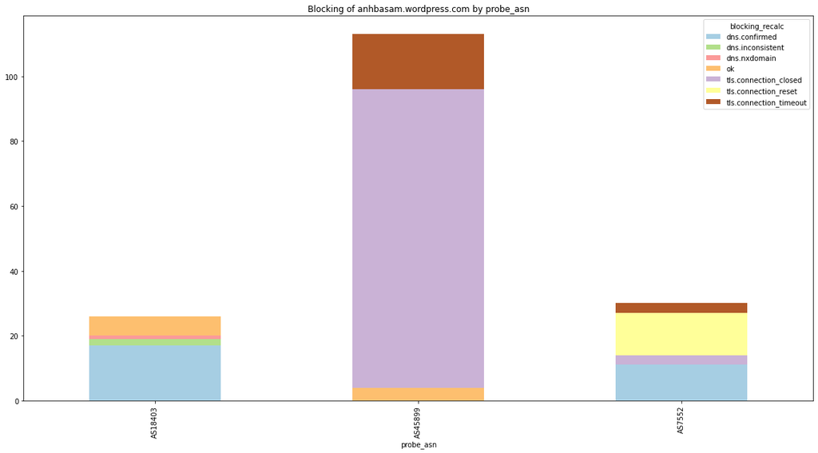

```python
plot_by_asn('anhbasam.wordpress.com')
```

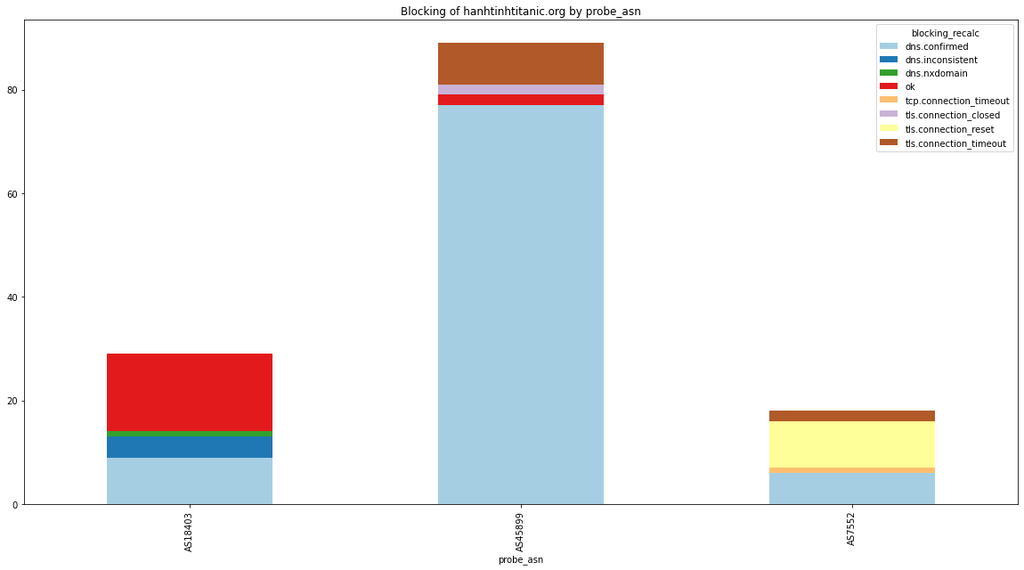

```python
plot_by_asn('hanhtinhtitanic.org')
```

As we can see above, the means through which blocking is implemented across different ISPs varies significantly. In some of them, we can also see that the block is not being implemented at all.

We can use the above chart to navigate our exploration of individual measurements on a per-ISP basis.

```python
def plot_blocking(probe_asn, domain):
    to_plot = df_vn_filter[
        (df_vn_filter['probe_asn'] == probe_asn)
        & (df_vn_filter['domain'] == domain)
        & (df_vn_filter['blocking_recalc'] != 'invalid')
    ][['blocking_recalc', 'measurement_start_time']]
    to_plot['measurement_start_time'] = pd.to_datetime(to_plot['measurement_start_time'])
    to_plot['count'] = 1
    (
    to_plot.pivot_table(
        columns='blocking_recalc',
        index='measurement_start_time',
        values='count',
        aggfunc='sum'
    ).reset_index()
        .groupby(pd.Grouper(key='measurement_start_time', freq='W'))
        .sum().reset_index()
        .set_index('measurement_start_time')
        .plot(kind='bar', stacked=True, title=f"{probe_asn} {domain}", colormap='Paired', figsize=(20,8))
    )
```

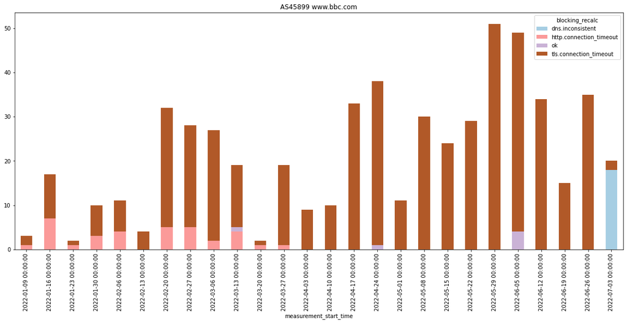

```python
plot_blocking('AS45899', 'www.bbc.com')
```

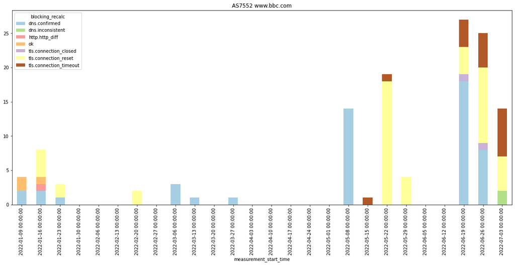

```python
plot_blocking('AS7552', 'www.bbc.com')
```

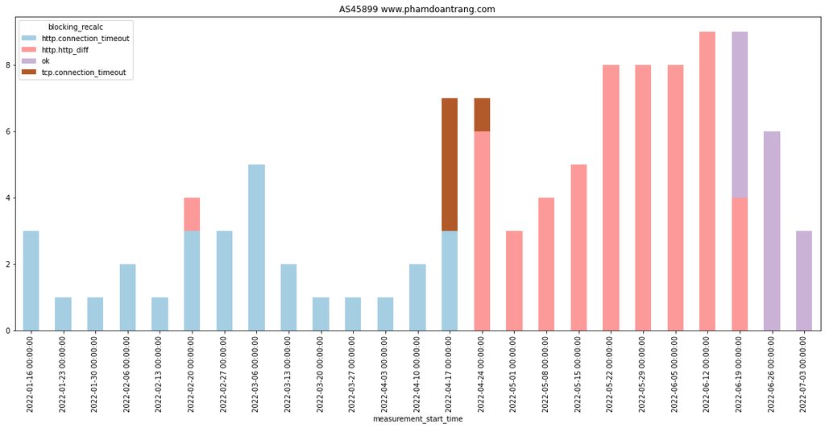

```python
plot_blocking('AS45899', 'www.phamdoantrang.com')
```

```python
df_vn_filter[
    (df_vn_filter['blocking_recalc'] == 'dns.confirmed')
    & (df_vn_filter['probe_asn'] == 'AS7552')
    & (df_vn_filter['domain'] == 'www.bbc.com')
]
```

|  | Unnamed: 0 | Unnamed: 0.1 | input | measurement_start_time | probe_asn | probe_cc | probe_network_name | report_id | resolver_asn | resolver_ip | ... | control_measurement | blocking | http_experiment_failure | dns_experiment_failure | http_title | http_meta_title | http_body_md5 | tcp_connect | domain | blocking_recalc |
| --- | --- | --- | --- | --- | --- | --- | --- | --- | --- | --- | --- | --- | --- | --- | --- | --- | --- | --- | --- | --- | --- |
| 20 | 20 | 20 | http://www.bbc.com/ | 2022-01-03 14:19:39 | AS7552 | VN | <unknown> | 20220103T141931Z_webconnectivity_VN_7552_n1_qj... | AS7552 | 2402:800:20ff:100f:3ea8:2aff:fe1c:2b04 | ... | {'tcp_connect': {'127.0.0.1:80': {'status': Tr... | dns | connection_refused | None | NaN | NaN | NaN | [{'ip': '127.0.0.1', 'port': 80, 'status': {'b... | www.bbc.com | dns.confirmed |
| 421 | 421 | 432 | https://www.bbc.com/vietnamese/ | 2022-01-08 09:36:21 | AS7552 | VN | <unknown> | 20220108T093135Z_webconnectivity_VN_7552_n1_wQ... | AS7552 | 27.71.195.69 | ... | {'tcp_connect': {'127.0.0.1:443': {'status': T... | dns | connection_refused | None | NaN | NaN | NaN | [{'ip': '127.0.0.1', 'port': 443, 'status': {'... | www.bbc.com | dns.confirmed |
| 3356 | 3356 | 3498 | http://www.bbc.com/news | 2022-01-14 04:16:29 | AS7552 | VN | <unknown> | 20220114T040859Z_webconnectivity_VN_7552_n1_ku... | AS7552 | 27.71.195.88 | ... | {'tcp_connect': {'127.0.0.1:80': {'status': Tr... | dns | connection_refused | None | NaN | NaN | NaN | [{'ip': '127.0.0.1', 'port': 80, 'status': {'b... | www.bbc.com | dns.confirmed |
| 3515 | 3515 | 3663 | https://www.bbc.com/vietnamese/vietnam/ | 2022-01-14 04:40:27 | AS7552 | VN | <unknown> | 20220114T043306Z_webconnectivity_VN_7552_n1_sZ... | AS7552 | 27.71.195.84 | ... | {'tcp_connect': {'127.0.0.1:443': {'status': T... | dns | connection_refused | None | NaN | NaN | NaN | [{'ip': '127.0.0.1', 'port': 443, 'status': {'... | www.bbc.com | dns.confirmed |
| 9039 | 9039 | 9394 | http://www.bbc.com/news | 2022-01-22 11:35:40 | AS7552 | VN | <unknown> | 20220122T112801Z_webconnectivity_VN_7552_n1_KW... | AS7552 | 171.229.17.147 | ... | {'tcp_connect': {'127.0.0.1:80': {'status': Tr... | dns | connection_refused | None | NaN | NaN | NaN | [{'ip': '127.0.0.1', 'port': 80, 'status': {'b... | www.bbc.com | dns.confirmed |
| 52581 | 52581 | 54740 | https://www.bbc.com/ | 2022-03-03 07:38:41 | AS7552 | VN | Viettel Group | 20220303T073836Z_webconnectivity_VN_7552_n1_ND... | AS7552 | 116.97.91.51 | ... | {'tcp_connect': {'127.0.0.1:443': {'status': T... | dns | connection_refused | None | NaN | NaN | NaN | [{'ip': '::1', 'port': 443, 'status': {'blocke... | www.bbc.com | dns.confirmed |
| 52582 | 52582 | 54741 | https://www.bbc.com/news | 2022-03-03 07:38:42 | AS7552 | VN | Viettel Group | 20220303T073836Z_webconnectivity_VN_7552_n1_ND... | AS7552 | 116.97.91.51 | ... | {'tcp_connect': {'127.0.0.1:443': {'status': T... | dns | connection_refused | None | NaN | NaN | NaN | [{'ip': '::1', 'port': 443, 'status': {'blocke... | www.bbc.com | dns.confirmed |
| 52583 | 52583 | 54742 | https://www.bbc.com/vietnamese/ | 2022-03-03 07:38:43 | AS7552 | VN | Viettel Group | 20220303T073836Z_webconnectivity_VN_7552_n1_ND... | AS7552 | 116.97.91.51 | ... | {'tcp_connect': {'127.0.0.1:443': {'status': T... | dns | connection_refused | None | NaN | NaN | NaN | [{'ip': '127.0.0.1', 'port': 443, 'status': {'... | www.bbc.com | dns.confirmed |
| 92808 | 92808 | 96504 | https://www.bbc.com/ | 2022-03-12 15:57:40 | AS7552 | VN | <unknown> | 20220316T015523Z_webconnectivity_VN_7552_n1_Wi... | AS7552 | 27.71.193.103 | ... | {'dns': {'addrs': ['www.bbc.com.pri.bbc.com', ... | dns | connection_refused | None | NaN | NaN | NaN | [{'ip': '::1', 'port': 443, 'status': {'blocke... | www.bbc.com | dns.confirmed |
| 108632 | 108632 | 112732 | https://www.bbc.com/ | 2022-03-21 15:24:53 | AS7552 | VN | Viettel Group | 20220321T152425Z_webconnectivity_VN_7552_n1_xj... | AS7552 | 27.68.242.250 | ... | {'tcp_connect': {'127.0.0.1:443': {'status': T... | dns | connection_refused | None | NaN | NaN | NaN | [{'ip': '127.0.0.1', 'port': 443, 'status': {'... | www.bbc.com | dns.confirmed |
| 163670 | 163670 | 169242 | https://www.bbc.com/ | 2022-05-04 19:47:26 | AS7552 | VN | Viettel Group | 20220504T193412Z_webconnectivity_VN_7552_n1_hj... | AS7552 | 27.68.246.201 | ... | {'tcp_connect': {'127.0.0.1:443': {'status': T... | dns | connection_refused | None | NaN | NaN | NaN | [{'ip': '::1', 'port': 443, 'status': {'blocke... | www.bbc.com | dns.confirmed |
| 163671 | 163671 | 169243 | https://www.bbc.com/news | 2022-05-04 19:47:26 | AS7552 | VN | Viettel Group | 20220504T193412Z_webconnectivity_VN_7552_n1_hj... | AS7552 | 27.68.246.201 | ... | {'tcp_connect': {'127.0.0.1:443': {'status': T... | dns | connection_refused | None | NaN | NaN | NaN | [{'ip': '127.0.0.1', 'port': 443, 'status': {'... | www.bbc.com | dns.confirmed |
| 163672 | 163672 | 169244 | https://www.bbc.com/vietnamese/ | 2022-05-04 19:47:27 | AS7552 | VN | Viettel Group | 20220504T193412Z_webconnectivity_VN_7552_n1_hj... | AS7552 | 27.68.246.201 | ... | {'tcp_connect': {'127.0.0.1:443': {'status': T... | dns | connection_refused | None | NaN | NaN | NaN | [{'ip': '127.0.0.1', 'port': 443, 'status': {'... | www.bbc.com | dns.confirmed |
| 163677 | 163677 | 169249 | https://www.bbc.com/vietnamese/vietnam/ | 2022-05-04 20:31:19 | AS7552 | VN | Viettel Group | 20220504T203106Z_webconnectivity_VN_7552_n1_zM... | AS7552 | 27.68.246.34 | ... | {'tcp_connect': {'127.0.0.1:443': {'status': T... | dns | connection_refused | None | NaN | NaN | NaN | [{'ip': '127.0.0.1', 'port': 443, 'status': {'... | www.bbc.com | dns.confirmed |
| 165734 | 165734 | 171345 | https://www.bbc.com/ | 2022-05-05 12:49:08 | AS7552 | VN | Viettel Group | 20220505T123116Z_webconnectivity_VN_7552_n1_zQ... | AS7552 | 117.6.149.223 | ... | {'tcp_connect': {'127.0.0.1:443': {'status': T... | dns | connection_refused | None | NaN | NaN | NaN | [{'ip': '127.0.0.1', 'port': 443, 'status': {'... | www.bbc.com | dns.confirmed |
| 165735 | 165735 | 171346 | https://www.bbc.com/news | 2022-05-05 12:49:09 | AS7552 | VN | Viettel Group | 20220505T123116Z_webconnectivity_VN_7552_n1_zQ... | AS7552 | 117.6.149.223 | ... | {'tcp_connect': {'127.0.0.1:443': {'status': T... | dns | connection_refused | None | NaN | NaN | NaN | [{'ip': '127.0.0.1', 'port': 443, 'status': {'... | www.bbc.com | dns.confirmed |
| 165736 | 165736 | 171347 | https://www.bbc.com/vietnamese/ | 2022-05-05 12:49:10 | AS7552 | VN | Viettel Group | 20220505T123116Z_webconnectivity_VN_7552_n1_zQ... | AS7552 | 117.6.149.223 | ... | {'tcp_connect': {'127.0.0.1:443': {'status': T... | dns | connection_refused | None | NaN | NaN | NaN | [{'ip': '127.0.0.1', 'port': 443, 'status': {'... | www.bbc.com | dns.confirmed |
| 165737 | 165737 | 171348 | https://www.bbc.com/vietnamese/vietnam/ | 2022-05-05 12:49:11 | AS7552 | VN | Viettel Group | 20220505T123116Z_webconnectivity_VN_7552_n1_zQ... | AS7552 | 117.6.149.223 | ... | {'tcp_connect': {'127.0.0.1:443': {'status': T... | dns | connection_refused | None | NaN | NaN | NaN | [{'ip': '127.0.0.1', 'port': 443, 'status': {'... | www.bbc.com | dns.confirmed |
| 166681 | 166681 | 172310 | https://www.bbc.com/news/world-51235105 | 2022-05-05 20:33:48 | AS7552 | VN | Viettel Group | 20220505T203050Z_webconnectivity_VN_7552_n1_IA... | AS7552 | 27.68.247.132 | ... | {'tcp_connect': {'127.0.0.1:443': {'status': T... | dns | connection_refused | None | NaN | NaN | NaN | [{'ip': '::1', 'port': 443, 'status': {'blocke... | www.bbc.com | dns.confirmed |
| 170446 | 170446 | 176173 | https://www.bbc.com/news/world-51235105 | 2022-05-07 03:31:44 | AS7552 | VN | Viettel Group | 20220507T033132Z_webconnectivity_VN_7552_n1_40... | AS7552 | 27.68.246.166 | ... | {'tcp_connect': {'127.0.0.1:443': {'status': T... | dns | connection_refused | None | NaN | NaN | NaN | [{'ip': '::1', 'port': 443, 'status': {'blocke... | www.bbc.com | dns.confirmed |
| 170917 | 170917 | 176656 | https://www.bbc.com/ | 2022-05-07 06:40:29 | AS7552 | VN | Viettel Group | 20220507T063100Z_webconnectivity_VN_7552_n1_VZ... | AS7552 | 117.6.149.131 | ... | {'tcp_connect': {'127.0.0.1:443': {'status': T... | dns | connection_refused | None | NaN | NaN | NaN | [{'ip': '127.0.0.1', 'port': 443, 'status': {'... | www.bbc.com | dns.confirmed |
| 170918 | 170918 | 176657 | https://www.bbc.com/news | 2022-05-07 06:40:30 | AS7552 | VN | Viettel Group | 20220507T063100Z_webconnectivity_VN_7552_n1_VZ... | AS7552 | 117.6.149.131 | ... | {'tcp_connect': {'127.0.0.1:443': {'status': T... | dns | connection_refused | None | NaN | NaN | NaN | [{'ip': '127.0.0.1', 'port': 443, 'status': {'... | www.bbc.com | dns.confirmed |
| 170919 | 170919 | 176658 | https://www.bbc.com/vietnamese/ | 2022-05-07 06:40:31 | AS7552 | VN | Viettel Group | 20220507T063100Z_webconnectivity_VN_7552_n1_VZ... | AS7552 | 117.6.149.131 | ... | {'tcp_connect': {'127.0.0.1:443': {'status': T... | dns | connection_refused | None | NaN | NaN | NaN | [{'ip': '127.0.0.1', 'port': 443, 'status': {'... | www.bbc.com | dns.confirmed |
| 170920 | 170920 | 176659 | https://www.bbc.com/vietnamese/vietnam/ | 2022-05-07 06:40:32 | AS7552 | VN | Viettel Group | 20220507T063100Z_webconnectivity_VN_7552_n1_VZ... | AS7552 | 117.6.149.131 | ... | {'tcp_connect': {'127.0.0.1:443': {'status': T... | dns | connection_refused | None | NaN | NaN | NaN | [{'ip': '127.0.0.1', 'port': 443, 'status': {'... | www.bbc.com | dns.confirmed |
| 243828 | 243828 | 251386 | https://www.bbc.com/ | 2022-06-13 04:59:09 | AS7552 | VN | Viettel Group | 20220613T045226Z_webconnectivity_VN_7552_n1_e0... | AS7552 | 117.6.149.219 | ... | {'tcp_connect': {'127.0.0.1:443': {'status': T... | dns | connection_refused | None | NaN | NaN | NaN | [{'ip': '127.0.0.1', 'port': 443, 'status': {'... | www.bbc.com | dns.confirmed |
| 243829 | 243829 | 251387 | https://www.bbc.com/news | 2022-06-13 04:59:10 | AS7552 | VN | Viettel Group | 20220613T045226Z_webconnectivity_VN_7552_n1_e0... | AS7552 | 117.6.149.219 | ... | {'tcp_connect': {'127.0.0.1:443': {'status': T... | dns | connection_refused | None | NaN | NaN | NaN | [{'ip': '127.0.0.1', 'port': 443, 'status': {'... | www.bbc.com | dns.confirmed |
| 243830 | 243830 | 251388 | https://www.bbc.com/vietnamese/ | 2022-06-13 04:59:10 | AS7552 | VN | Viettel Group | 20220613T045226Z_webconnectivity_VN_7552_n1_e0... | AS7552 | 117.6.149.219 | ... | {'tcp_connect': {'127.0.0.1:443': {'status': T... | dns | connection_refused | None | NaN | NaN | NaN | [{'ip': '127.0.0.1', 'port': 443, 'status': {'... | www.bbc.com | dns.confirmed |
| 243831 | 243831 | 251389 | https://www.bbc.com/vietnamese/vietnam/ | 2022-06-13 04:59:12 | AS7552 | VN | Viettel Group | 20220613T045226Z_webconnectivity_VN_7552_n1_e0... | AS7552 | 117.6.149.219 | ... | {'tcp_connect': {'127.0.0.1:443': {'status': T... | dns | connection_refused | None | NaN | NaN | NaN | [{'ip': '127.0.0.1', 'port': 443, 'status': {'... | www.bbc.com | dns.confirmed |
| 244304 | 244304 | 251872 | https://www.bbc.com/ | 2022-06-13 08:01:53 | AS7552 | VN | Viettel Group | 20220613T075218Z_webconnectivity_VN_7552_n1_6y... | AS7552 | 117.6.149.203 | ... | {'tcp_connect': {'127.0.0.1:443': {'status': T... | dns | connection_refused | None | NaN | NaN | NaN | [{'ip': '127.0.0.1', 'port': 443, 'status': {'... | www.bbc.com | dns.confirmed |
| 244305 | 244305 | 251873 | https://www.bbc.com/news | 2022-06-13 08:01:53 | AS7552 | VN | Viettel Group | 20220613T075218Z_webconnectivity_VN_7552_n1_6y... | AS7552 | 117.6.149.203 | ... | {'tcp_connect': {'127.0.0.1:443': {'status': T... | dns | connection_refused | None | NaN | NaN | NaN | [{'ip': '127.0.0.1', 'port': 443, 'status': {'... | www.bbc.com | dns.confirmed |
| 244306 | 244306 | 251874 | https://www.bbc.com/vietnamese/ | 2022-06-13 08:01:54 | AS7552 | VN | Viettel Group | 20220613T075218Z_webconnectivity_VN_7552_n1_6y... | AS7552 | 117.6.149.203 | ... | {'tcp_connect': {'127.0.0.1:443': {'status': T... | dns | connection_refused | None | NaN | NaN | NaN | [{'ip': '127.0.0.1', 'port': 443, 'status': {'... | www.bbc.com | dns.confirmed |
| 244307 | 244307 | 251875 | https://www.bbc.com/vietnamese/vietnam/ | 2022-06-13 08:01:56 | AS7552 | VN | Viettel Group | 20220613T075218Z_webconnectivity_VN_7552_n1_6y... | AS7552 | 117.6.149.203 | ... | {'tcp_connect': {'127.0.0.1:443': {'status': T... | dns | connection_refused | None | NaN | NaN | NaN | [{'ip': '127.0.0.1', 'port': 443, 'status': {'... | www.bbc.com | dns.confirmed |
| 245405 | 245405 | 253039 | https://www.bbc.com/ | 2022-06-13 16:04:30 | AS7552 | VN | Viettel Group | 20220613T155219Z_webconnectivity_VN_7552_n1_N1... | AS7552 | 117.6.149.137 | ... | {'tcp_connect': {'127.0.0.1:443': {'status': T... | dns | connection_refused | None | NaN | NaN | NaN | [{'ip': '::1', 'port': 443, 'status': {'blocke... | www.bbc.com | dns.confirmed |
| 245406 | 245406 | 253040 | https://www.bbc.com/news | 2022-06-13 16:04:30 | AS7552 | VN | Viettel Group | 20220613T155219Z_webconnectivity_VN_7552_n1_N1... | AS7552 | 117.6.149.137 | ... | {'tcp_connect': {'127.0.0.1:443': {'status': T... | dns | connection_refused | None | NaN | NaN | NaN | [{'ip': '127.0.0.1', 'port': 443, 'status': {'... | www.bbc.com | dns.confirmed |
| 245407 | 245407 | 253041 | https://www.bbc.com/vietnamese/ | 2022-06-13 16:04:33 | AS7552 | VN | Viettel Group | 20220613T155219Z_webconnectivity_VN_7552_n1_N1... | AS7552 | 117.6.149.137 | ... | {'tcp_connect': {'127.0.0.1:443': {'status': T... | dns | connection_refused | None | NaN | NaN | NaN | [{'ip': '127.0.0.1', 'port': 443, 'status': {'... | www.bbc.com | dns.confirmed |
| 245408 | 245408 | 253042 | https://www.bbc.com/vietnamese/vietnam/ | 2022-06-13 16:04:34 | AS7552 | VN | Viettel Group | 20220613T155219Z_webconnectivity_VN_7552_n1_N1... | AS7552 | 117.6.149.137 | ... | {'tcp_connect': {'127.0.0.1:443': {'status': T... | dns | connection_refused | None | NaN | NaN | NaN | [{'ip': '127.0.0.1', 'port': 443, 'status': {'... | www.bbc.com | dns.confirmed |
| 246032 | 246032 | 253674 | https://www.bbc.com/news/world-51235105 | 2022-06-13 17:59:46 | AS7552 | VN | Viettel Group | 20220613T175222Z_webconnectivity_VN_7552_n1_JH... | AS7552 | 27.68.246.174 | ... | {'tcp_connect': {'127.0.0.1:443': {'status': T... | dns | connection_refused | None | NaN | NaN | NaN | [{'ip': '127.0.0.1', 'port': 443, 'status': {'... | www.bbc.com | dns.confirmed |
| 252359 | 252359 | 260182 | https://www.bbc.com/ | 2022-06-16 19:31:31 | AS7552 | VN | Viettel Group | 20220616T191022Z_webconnectivity_VN_7552_n1_RY... | AS7552 | 27.68.247.132 | ... | {'tcp_connect': {'127.0.0.1:443': {'status': T... | dns | connection_refused | None | NaN | NaN | NaN | [{'ip': '::1', 'port': 443, 'status': {'blocke... | www.bbc.com | dns.confirmed |
| 252360 | 252360 | 260183 | https://www.bbc.com/news | 2022-06-16 19:31:33 | AS7552 | VN | Viettel Group | 20220616T191022Z_webconnectivity_VN_7552_n1_RY... | AS7552 | 27.68.247.132 | ... | {'tcp_connect': {'127.0.0.1:443': {'status': T... | dns | connection_refused | None | NaN | NaN | NaN | [{'ip': '127.0.0.1', 'port': 443, 'status': {'... | www.bbc.com | dns.confirmed |
| 252361 | 252361 | 260184 | https://www.bbc.com/vietnamese/ | 2022-06-16 19:31:34 | AS7552 | VN | Viettel Group | 20220616T191022Z_webconnectivity_VN_7552_n1_RY... | AS7552 | 27.68.247.132 | ... | {'tcp_connect': {'127.0.0.1:443': {'status': T... | dns | connection_refused | None | NaN | NaN | NaN | [{'ip': '127.0.0.1', 'port': 443, 'status': {'... | www.bbc.com | dns.confirmed |
| 252362 | 252362 | 260185 | https://www.bbc.com/vietnamese/vietnam/ | 2022-06-16 19:31:36 | AS7552 | VN | Viettel Group | 20220616T191022Z_webconnectivity_VN_7552_n1_RY... | AS7552 | 27.68.247.132 | ... | {'tcp_connect': {'127.0.0.1:443': {'status': T... | dns | connection_refused | None | NaN | NaN | NaN | [{'ip': '127.0.0.1', 'port': 443, 'status': {'... | www.bbc.com | dns.confirmed |
| 259720 | 259720 | 267643 | https://www.bbc.com/news/world-51235105 | 2022-06-19 07:07:25 | AS7552 | VN | Viettel Group | 20220619T070538Z_webconnectivity_VN_7552_n1_dW... | AS7552 | 117.6.149.207 | ... | {'tcp_connect': {'127.0.0.1:443': {'status': T... | dns | connection_refused | None | NaN | NaN | NaN | [{'ip': '127.0.0.1', 'port': 443, 'status': {'... | www.bbc.com | dns.confirmed |
| 282216 | 282216 | 290477 | https://www.bbc.com/ | 2022-06-26 14:04:10 | AS7552 | VN | Viettel Group | 20220626T135328Z_webconnectivity_VN_7552_n1_KO... | AS7552 | 27.68.247.140 | ... | {'tcp_connect': {'127.0.0.1:443': {'status': T... | dns | connection_refused | None | NaN | NaN | NaN | [{'ip': '127.0.0.1', 'port': 443, 'status': {'... | www.bbc.com | dns.confirmed |
| 282217 | 282217 | 290478 | https://www.bbc.com/news | 2022-06-26 14:04:11 | AS7552 | VN | Viettel Group | 20220626T135328Z_webconnectivity_VN_7552_n1_KO... | AS7552 | 27.68.247.140 | ... | {'tcp_connect': {'127.0.0.1:443': {'status': T... | dns | connection_refused | None | NaN | NaN | NaN | [{'ip': '127.0.0.1', 'port': 443, 'status': {'... | www.bbc.com | dns.confirmed |
| 282218 | 282218 | 290479 | https://www.bbc.com/vietnamese/ | 2022-06-26 14:04:12 | AS7552 | VN | Viettel Group | 20220626T135328Z_webconnectivity_VN_7552_n1_KO... | AS7552 | 27.68.247.140 | ... | {'tcp_connect': {'127.0.0.1:443': {'status': T... | dns | connection_refused | None | NaN | NaN | NaN | [{'ip': '127.0.0.1', 'port': 443, 'status': {'... | www.bbc.com | dns.confirmed |
| 282219 | 282219 | 290480 | https://www.bbc.com/vietnamese/vietnam/ | 2022-06-26 14:04:15 | AS7552 | VN | Viettel Group | 20220626T135328Z_webconnectivity_VN_7552_n1_KO... | AS7552 | 27.68.247.140 | ... | {'tcp_connect': {'127.0.0.1:443': {'status': T... | dns | connection_refused | None | NaN | NaN | NaN | [{'ip': '127.0.0.1', 'port': 443, 'status': {'... | www.bbc.com | dns.confirmed |
| 283399 | 283399 | 291678 | https://www.bbc.com/ | 2022-06-26 20:03:23 | AS7552 | VN | Viettel Group | 20220626T195324Z_webconnectivity_VN_7552_n1_9k... | AS7552 | 27.68.246.46 | ... | {'tcp_connect': {'127.0.0.1:443': {'status': T... | dns | connection_refused | None | NaN | NaN | NaN | [{'ip': '127.0.0.1', 'port': 443, 'status': {'... | www.bbc.com | dns.confirmed |
| 283400 | 283400 | 291679 | https://www.bbc.com/news | 2022-06-26 20:03:24 | AS7552 | VN | Viettel Group | 20220626T195324Z_webconnectivity_VN_7552_n1_9k... | AS7552 | 27.68.246.46 | ... | {'tcp_connect': {'127.0.0.1:443': {'status': T... | dns | connection_refused | None | NaN | NaN | NaN | [{'ip': '127.0.0.1', 'port': 443, 'status': {'... | www.bbc.com | dns.confirmed |
| 283401 | 283401 | 291680 | https://www.bbc.com/vietnamese/ | 2022-06-26 20:03:25 | AS7552 | VN | Viettel Group | 20220626T195324Z_webconnectivity_VN_7552_n1_9k... | AS7552 | 27.68.246.46 | ... | {'tcp_connect': {'127.0.0.1:443': {'status': T... | dns | connection_refused | None | NaN | NaN | NaN | [{'ip': '127.0.0.1', 'port': 443, 'status': {'... | www.bbc.com | dns.confirmed |
| 283402 | 283402 | 291681 | https://www.bbc.com/vietnamese/vietnam/ | 2022-06-26 20:03:28 | AS7552 | VN | Viettel Group | 20220626T195324Z_webconnectivity_VN_7552_n1_9k... | AS7552 | 27.68.246.46 | ... | {'tcp_connect': {'127.0.0.1:443': {'status': T... | dns | connection_refused | None | NaN | NaN | NaN | [{'ip': '127.0.0.1', 'port': 443, 'status': {'... | www.bbc.com | dns.confirmed |

50 rows × 32 columns

```python
df_vn_filter['blocking_recalc'].value_counts()
```

```
ok                         264398
dns.inconsistent             7250
tls.connection_timeout       5380
invalid                      4184
dns.confirmed                3324
http.http_diff               2896
http.connection_timeout      2169
http.connection_closed        855
tls.connection_closed         839
tcp.connection_timeout        831
tls.connection_reset          603
dns.nxdomain                  460
dns.bogon                     104
http.connection_reset          86
http.generic_failure           19
tls.generic_failure             7
dns.no_ipv4                     5
tls.mitm                        5
Name: blocking_recalc, dtype: int64
```

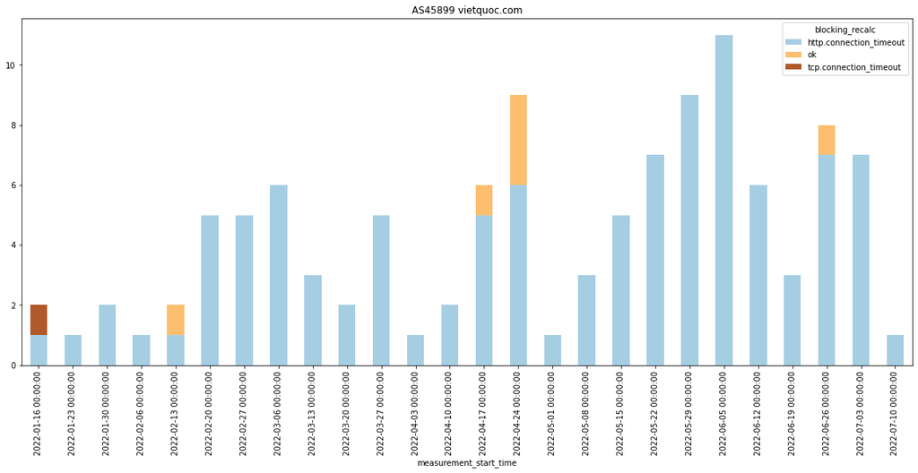

```python
plot_blocking('AS45899', 'vietquoc.com')
```

```python
data_export = df_vn_filter[['domain', 'measurement_start_time', 'probe_asn', 'report_id', 'blocking_recalc']]
```

```python
data_export['count'] = 1
```

At this point we would iterate the process of filtering out any additional false positives and false negatives, until we feel quite confident that we have eliminated most of the outliers (or come up with an explaination as to why we are seeing them).

Once this process is done, it might be desirable to create a CSV export of this cleaned data in preparation for publication ready charts (ex. through tools like Tableau).

Since charting tools generally work best with data where the values you need to plot are in the cells and the columns indicate the category of the value, we will reshape the data using the `pivot_table` function. This basically takes the values of `blocking_recalc` and puts them as columns, the value of the cells, in this case, is always going to be one. It's generally quite easy to do further aggregation and grouping inside of the charting tool itself.

```python
data_export.pivot_table(
    index=['probe_asn', 'domain', 'measurement_start_time', 'report_id'],
    columns=['blocking_recalc'],
    values='count'
).reset_index().to_csv('2022-vietnam_websites.csv')
```